# Lesson 4

### Calculating Age with Months

Notes: Current date is Dec 2013

```r
pf$age_with_months <- (2013 - pf$dob_year) + (12 - pf$dob_month)/12
# We could also just do -
# pf$age_with_months <- pf$age + (12 - pf$dob_month)/12
head(pf)
```

```
##    userid age dob_day dob_year dob_month gender tenure friend_count
## 1 2094382  14      19     1999        11   male    266            0
## 2 1192601  14       2     1999        11 female      6            0
## 3 2083884  14      16     1999        11   male     13            0
## 4 1203168  14      25     1999        12 female     93            0
## 5 1733186  14       4     1999        12   male     82            0
## 6 1524765  14       1     1999        12   male     15            0
##   friendships_initiated likes likes_received mobile_likes
## 1                     0     0              0            0
## 2                     0     0              0            0
## 3                     0     0              0            0
## 4                     0     0              0            0
## 5                     0     0              0            0
## 6                     0     0              0            0
##   mobile_likes_received www_likes www_likes_received age_with_months
## 1                     0         0                  0        14.08333
## 2                     0         0                  0        14.08333
## 3                     0         0                  0        14.08333
## 4                     0         0                  0        14.00000
## 5                     0         0                  0        14.00000
## 6                     0         0                  0        14.00000
```

### Age with Months Means solution

```r
pf.fc_by_age_months <- pf %>%
  group_by(age_with_months) %>%
  summarise(friend_count_mean = mean(friend_count),
            friend_count_median = median(friend_count),
            n = n()) %>%
  arrange(age_with_months)
```

### Noise in Conditional Means

```r
plot2 <- ggplot(data = subset(pf.fc_by_age_months, age_with_months < 71), aes(x = age_with_months, y = friend_count_mean)) +
  geom_smooth() +
  geom_line() +
  scale_x_continuous(limits = c(13, 71), breaks = seq(13, 71, 5))
```

### Smoothing Conditional Means

Notes: Compare against smoother plot

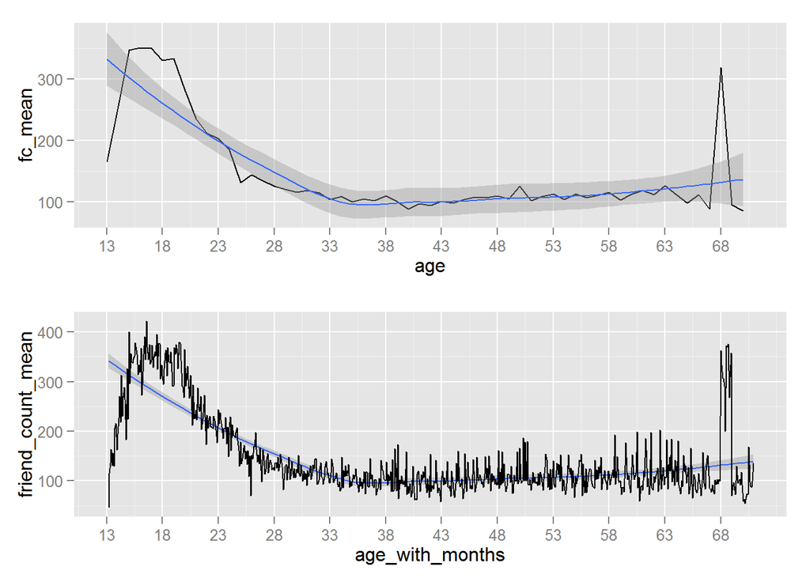

```r
plot1 <- ggplot(aes(x = age, y = fc_mean), data = subset(pf.fc_by_age, age < 71)) +
  geom_line() +
  geom_smooth() +
  scale_x_continuous(limits = c(13, 71), breaks = seq(13, 71, 5))

library(gridExtra)
grid.arrange(plot1, plot2, ncol = 1)
```

### Which Plot to Choose?

Notes: Choice is based on audience and it may be good to use different plots based on story you are trying to tell

### Analyzing Two Variables

Reflection: - scatter plots with geom_point() - adding jitter with geom_jitter() - using alpha for transparency to mitigate overplotting - Pipelines using dply with group_by(), summarise() and arrange() to calculate conditional means df - Overlaying mean, median and quantiles on top of scatter plots - calculating pearson’s coefficient with and doing a correlation test with cor.test() - Use correlation to not pick variables that are strongly correlated in feature set as this can lead to logistic/linear regression breaking down - multivariate ttest for independence between two variables using dcor.ttest() - conditional means plots with geom_line() after calculating a df with central measures using dply - noise and smoothing and which plots to choose

Click **KnitHTML** to see all of your hard work and to have an html page of this lesson, your answers, and your notes!